# STOR 455 Assignment 6

# Data Preparation

```r
library(Stat2Data)
library(bestglm)
StudentPerformance <- read.csv("~/Documents/(2) Sophomore Year/Second Semester (SPR 20)/STOR 455/CSV Files/studentPerformance.csv")
```

```r
head(StudentPerformance)
```

|  | gender | NationalITy | PlaceofBirth | StageID | GradeID | SectionID | Topic | Semester | Relation | raisedhands | VisITedResources | AnnouncementsView | Discussion | ParentAnsweringSurvey | ParentschoolSatisfaction | StudentAbsenceDays | Class |
| --- | --- | --- | --- | --- | --- | --- | --- | --- | --- | --- | --- | --- | --- | --- | --- | --- | --- |
| 1 | M | KW | KuwaIT | lowerlevel | G-04 | A | IT | F | Father | 15 | 16 | 2 | 20 | Yes | Good | Under-7 | M |
| 2 | M | KW | KuwaIT | lowerlevel | G-04 | A | IT | F | Father | 20 | 20 | 3 | 25 | Yes | Good | Under-7 | M |
| 3 | M | KW | KuwaIT | lowerlevel | G-04 | A | IT | F | Father | 10 | 7 | 0 | 30 | No | Bad | Above-7 | L |
| 4 | M | KW | KuwaIT | lowerlevel | G-04 | A | IT | F | Father | 30 | 25 | 5 | 35 | No | Bad | Above-7 | L |
| 5 | M | KW | KuwaIT | lowerlevel | G-04 | A | IT | F | Father | 40 | 50 | 12 | 50 | No | Bad | Above-7 | M |
| 6 | F | KW | KuwaIT | lowerlevel | G-04 | A | IT | F | Father | 42 | 30 | 13 | 70 | Yes | Bad | Above-7 | M |

Data was originally a csv file, so no extra manipulation was needed.

> Source: https://www.kaggle.com/aljarah/xAPI-Edu-Data/data

> Summary: This is an educational dataset that describes a group of 480 students in an attempt to learn more about the learning experience.

# Single Predictor

### Part (a)

```r
StudentPerformance$StudentAbsenceDays <- ifelse(StudentPerformance$StudentAbsenceDays=="Above-7", 1, 0)
```

“Above-7” absence days coded as “1”

```r
logitmod1 = glm(StudentAbsenceDays~Discussion, family=binomial, data=StudentPerformance)
```

### Part (b)

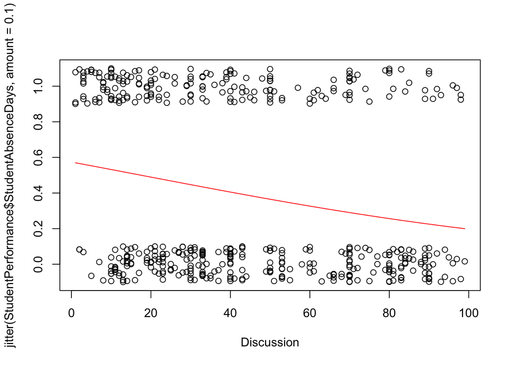

```r
B0 = summary(logitmod1)$coef[1]
B1 = summary(logitmod1)$coef[2]

plot(jitter(StudentPerformance$StudentAbsenceDays,amount=0.1)~Discussion,data=StudentPerformance)
curve(exp(B0+B1*x)/(1+exp(B0+B1*x)),add=TRUE, col="red")
```

### Part (c)

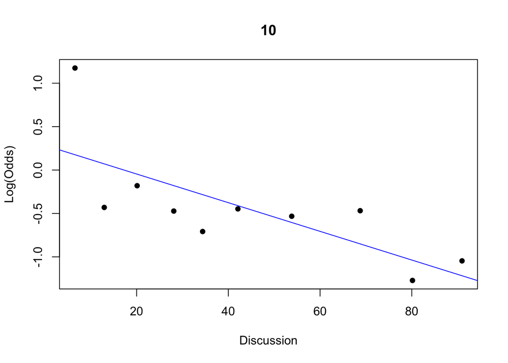

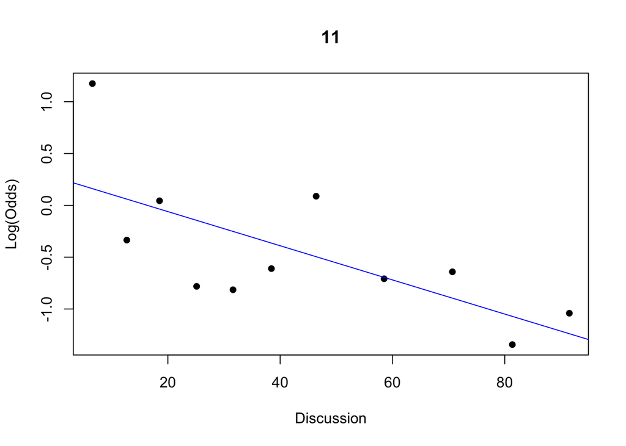

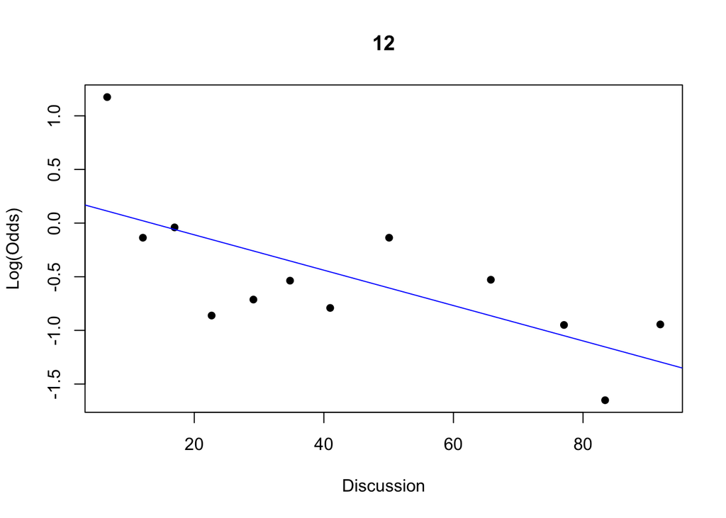

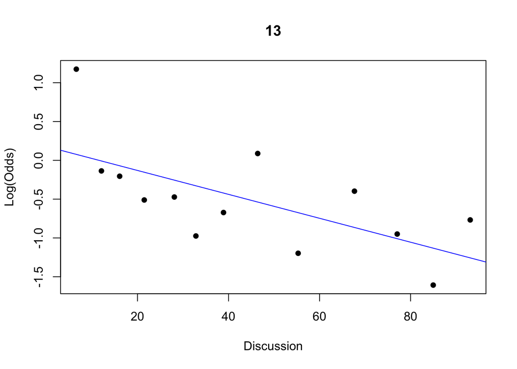

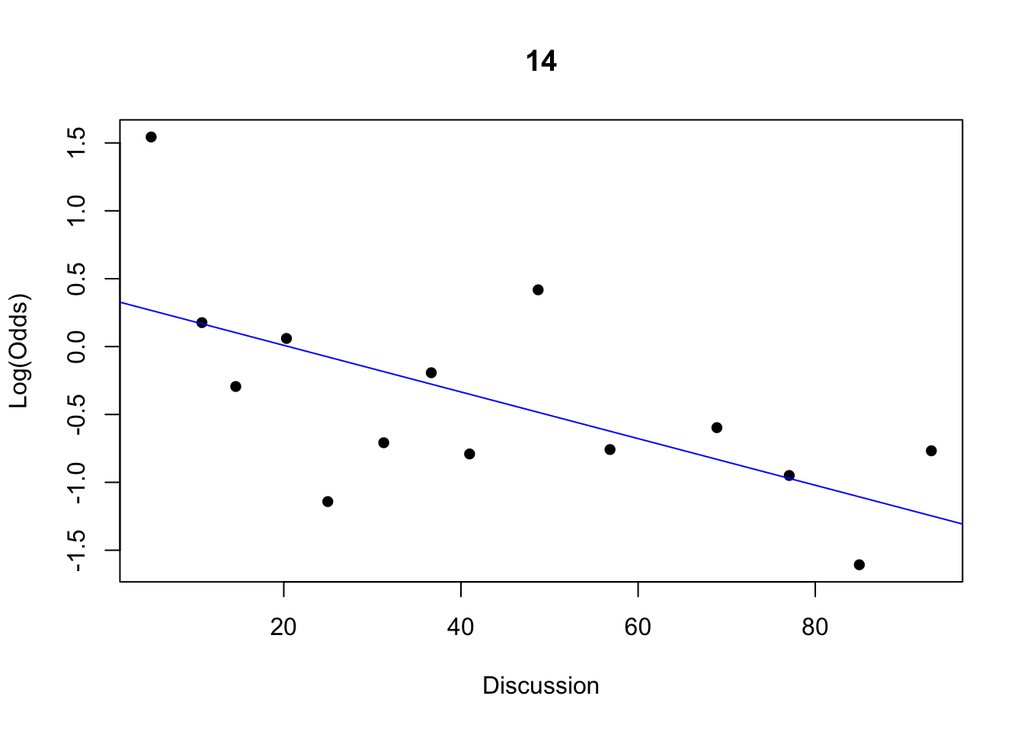

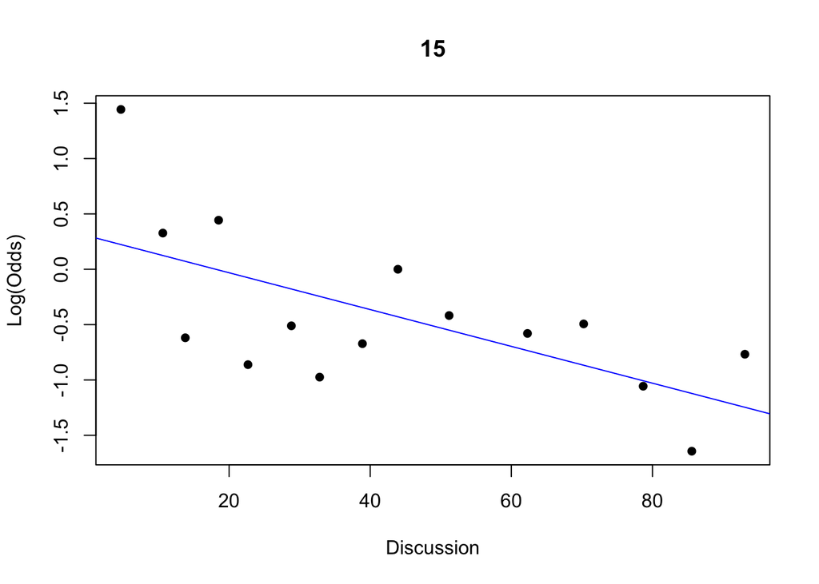

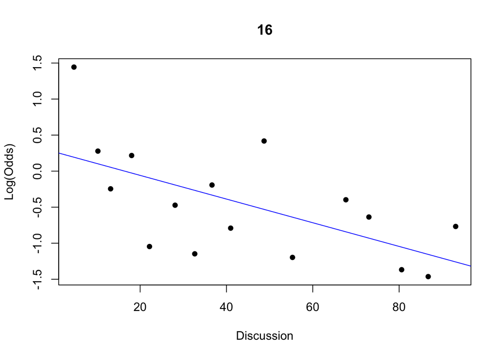

```r
for(j in 10:16){emplogitplot1(StudentAbsenceDays~Discussion, data=StudentPerformance, ngroups=j, main=j)}
```

Multiple empirical logit plots were taken to give a better idea of linearity.

Based on the above empirical logit plots, the data seems to be somewhat linear. There seems to be a single outlier in every variation of the plot, so taking that into account, we can comment further on the linearity. While the data points may not be fitted tightly about the regression line in every instance, they do follow the line realtively well and there doesn’t seem to be any distinct curvature in the points. Thus, we can say within reasonable doubt that the ‘StudentAbsenceDays’ varies linearly with respect to ‘Discussion’ participation.

### Part (d)

```r
summary(logitmod1)
```

```
##
## Call:
## glm(formula = StudentAbsenceDays ~ Discussion, family = binomial,
##     data = StudentPerformance)
##
## Deviance Residuals:
##     Min       1Q   Median       3Q      Max
## -1.2915  -1.0486  -0.7642   1.1955   1.7874
##
## Coefficients:
##              Estimate Std. Error z value Pr(>|z|)
## (Intercept)  0.298255   0.174124   1.713   0.0867 .
## Discussion  -0.017035   0.003616  -4.711 2.47e-06 ***
## ---
## Signif. codes:  0 '***' 0.001 '**' 0.01 '*' 0.05 '.' 0.1 ' ' 1
##
## (Dispersion parameter for binomial family taken to be 1)
##
##     Null deviance: 645.27  on 479  degrees of freedom
## Residual deviance: 621.65  on 478  degrees of freedom
## AIC: 625.65
##
## Number of Fisher Scoring iterations: 4
```

Null Hypothesis: there is no relationship between a student’s participation in discussions and their attendance (Beta = 0)

Alternate Hypothesis: there is some relationship between a student’s participation in discussions and their attendance (Beta /= 0)

With a p-value of 2.47e-06 (which is less than an arbitrarily chosen 0.05), we can reject the null hypothesis and conclude that there is some relationship between a student’s participation in discussions and their attendance.

### Part (e)

```r
SE_B1 = summary(logitmod1)$coef[2,2]
exp(B1 - SE_B1*qnorm(0.975))
```

```
## [1] 0.9761661
```

```r
exp(B1 + SE_B1*qnorm(0.975))
```

```
## [1] 0.9901022
```

```r
exp(confint.default(logitmod1))
```

```
##                 2.5 %    97.5 %
## (Intercept) 0.9578897 1.8955938
## Discussion  0.9761661 0.9901022
```

The confidence interval for the odds ratio (0.9761661, 0.9901022) shows that for every extra time a student participates in a discussion, they become less likely to have more than 7 absences. Both values are less than 1, meaning the odds of having more than 7 absences decreases as discussion participation increases (albeit by a very small amount). It is worth mentioning that the values being so close to 1 makes sense considering the values for ‘Discussion’ range from (1,99).

### Part (f)

```r
summary(logitmod1)
```

```
##
## Call:
## glm(formula = StudentAbsenceDays ~ Discussion, family = binomial,
##     data = StudentPerformance)
##
## Deviance Residuals:
##     Min       1Q   Median       3Q      Max
## -1.2915  -1.0486  -0.7642   1.1955   1.7874
##
## Coefficients:
##              Estimate Std. Error z value Pr(>|z|)
## (Intercept)  0.298255   0.174124   1.713   0.0867 .
## Discussion  -0.017035   0.003616  -4.711 2.47e-06 ***
## ---
## Signif. codes:  0 '***' 0.001 '**' 0.01 '*' 0.05 '.' 0.1 ' ' 1
##
## (Dispersion parameter for binomial family taken to be 1)
##
##     Null deviance: 645.27  on 479  degrees of freedom
## Residual deviance: 621.65  on 478  degrees of freedom
## AIC: 625.65
##
## Number of Fisher Scoring iterations: 4
```

Null Hypothesis: the model is not more effective with the added predictor ‘Discussion’ (Beta = 0)

Alternate Hypothesis: the model is more effective with the added predictor ‘Discussion’ (Beta /= 0)

```r
645.27 - 621.65
```

```
## [1] 23.62
```

```r
1-pchisq(23.62,1)
```

```
## [1] 1.173614e-06
```

G = 645.27 - 621.65 = 23.62

p-value = 1.173614e-06

Based on the p-value above (arbitrarily < 0.05), we can reject the null hypothesis and conclude that the model is more effective with the added predictor ‘Discussion’

### Part (g): Repeated steps using ‘raisedhands’ as the predictor

```r
logitmod2 = glm(StudentAbsenceDays~raisedhands, family=binomial, data=StudentPerformance)
```

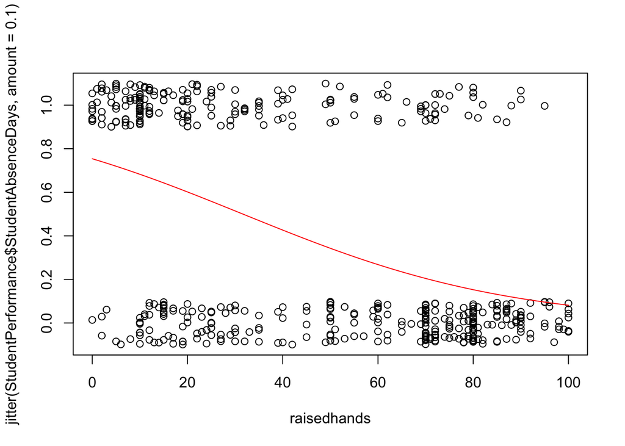

```r
B0 = summary(logitmod2)$coef[1]
B1 = summary(logitmod2)$coef[2]

plot(jitter(StudentPerformance$StudentAbsenceDays,amount=0.1)~raisedhands,data=StudentPerformance)
curve(exp(B0+B1*x)/(1+exp(B0+B1*x)),add=TRUE, col="red")
```

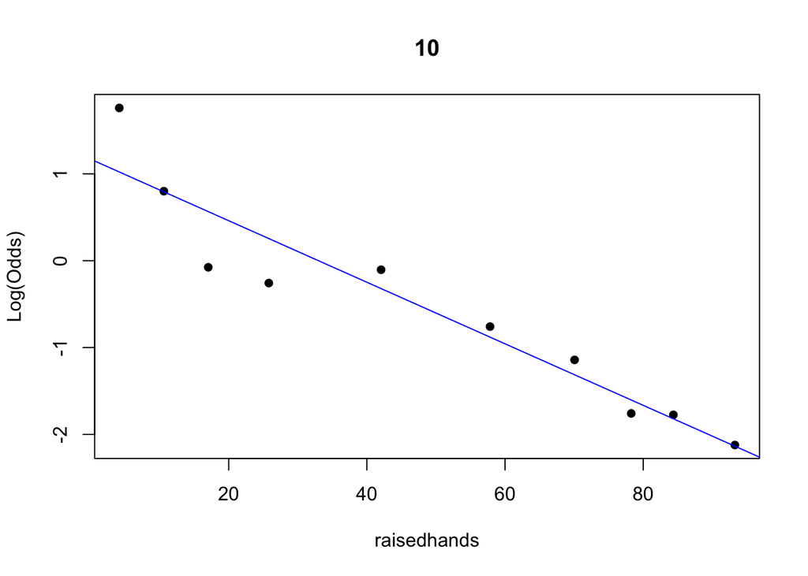

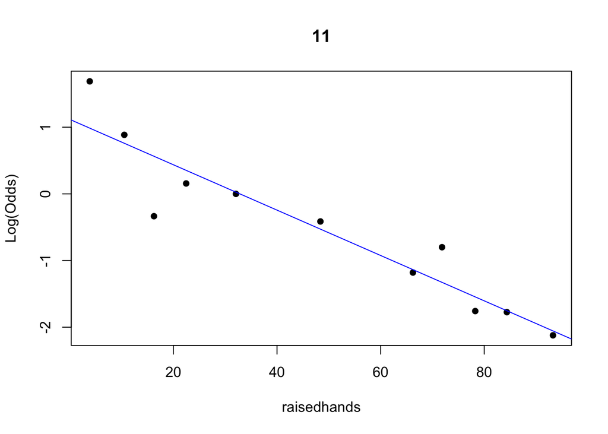

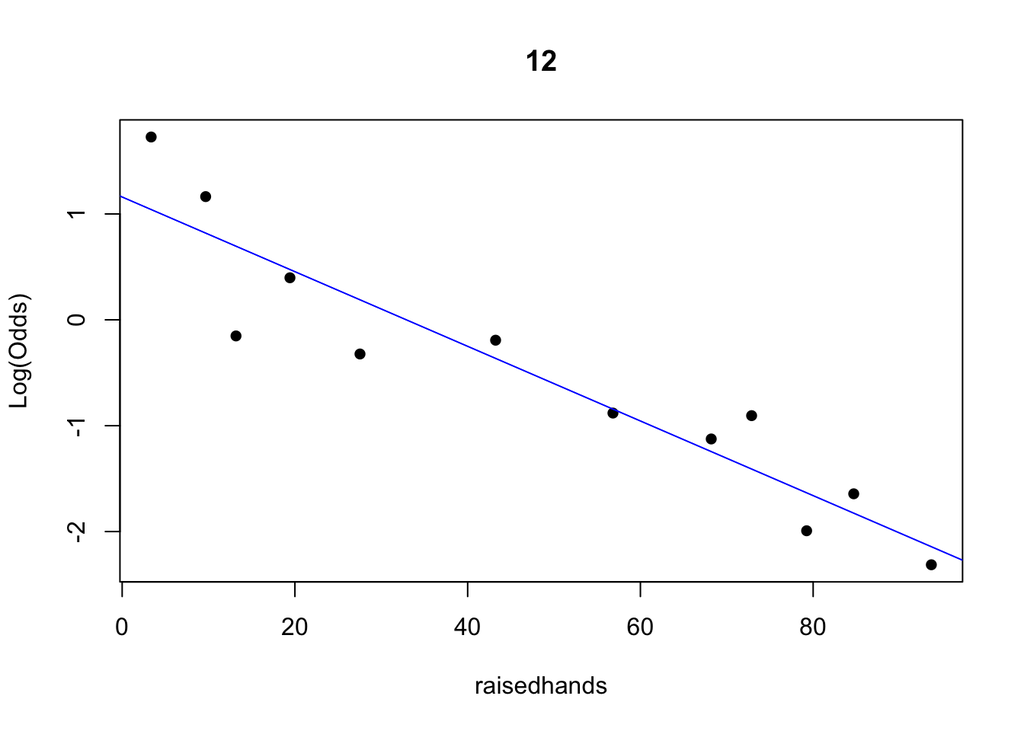

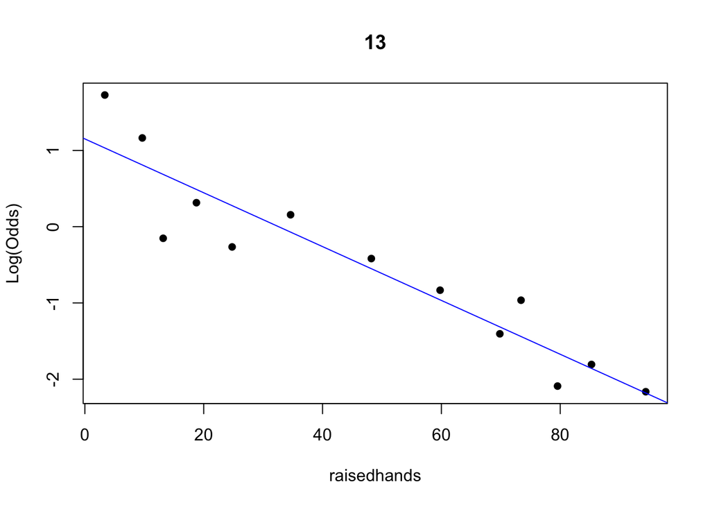

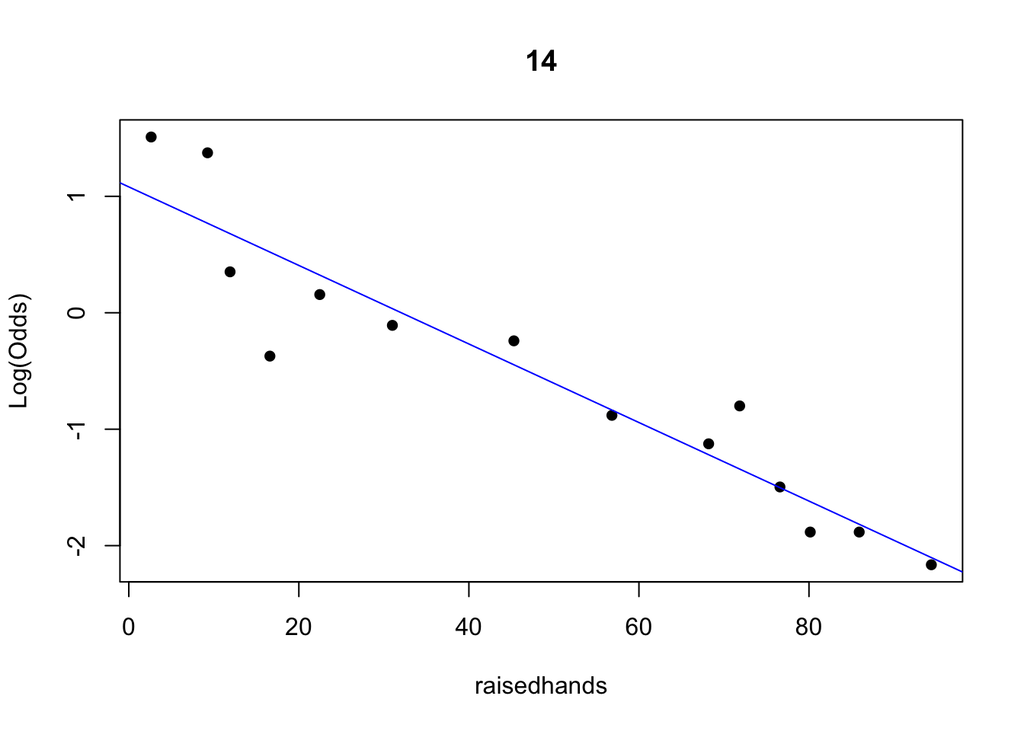

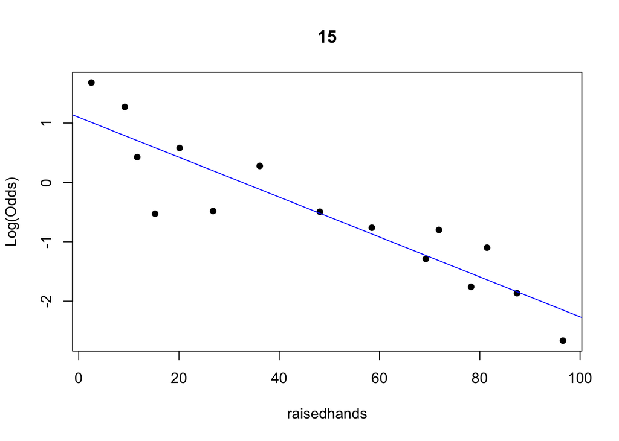

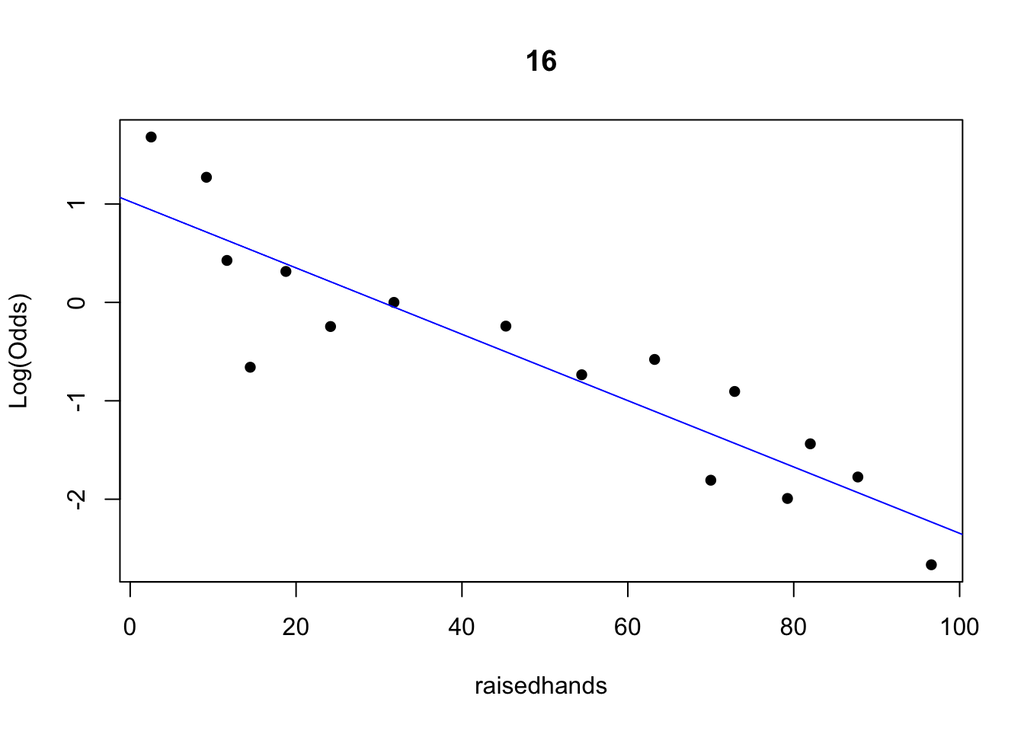

```r
for(j in 10:16){emplogitplot1(StudentAbsenceDays~raisedhands, data=StudentPerformance, ngroups=j, main=j)}
```

Multiple empirical logit plots were taken to give a better idea of linearity.

```r
summary(logitmod2)
```

```
##
## Call:
## glm(formula = StudentAbsenceDays ~ raisedhands, family = binomial,
##     data = StudentPerformance)
##
## Deviance Residuals:
##     Min       1Q   Median       3Q      Max
## -1.6748  -0.7901  -0.5306   0.8997   2.1653
##
## Coefficients:
##              Estimate Std. Error z value Pr(>|z|)
## (Intercept)  1.120188   0.182702   6.131 8.72e-10 ***
## raisedhands -0.035406   0.003737  -9.475  < 2e-16 ***
## ---
## Signif. codes:  0 '***' 0.001 '**' 0.01 '*' 0.05 '.' 0.1 ' ' 1
##
## (Dispersion parameter for binomial family taken to be 1)
##
##     Null deviance: 645.27  on 479  degrees of freedom
## Residual deviance: 534.82  on 478  degrees of freedom
## AIC: 538.82
##
## Number of Fisher Scoring iterations: 4
```

Null Hypothesis: there is no relationship between a student raising their hand more and their attendance (Beta = 0)

Alternate Hypothesis: there is some relationship between a student raising their hand more and their attendance (Beta /= 0)

```r
SE_B1 = summary(logitmod2)$coef[2,2]
exp(B1 - SE_B1*qnorm(0.975))
```

```
## [1] 0.9581694
```

```r
exp(B1 + SE_B1*qnorm(0.975))
```

```
## [1] 0.9723086
```

```r
exp(confint.default(logitmod2))
```

```
##                 2.5 %    97.5 %
## (Intercept) 2.1427695 4.3853792
## raisedhands 0.9581694 0.9723086
```

The confidence interval for the odds ratio (0.9581694, 0.9723086) shows that for every extra time a student raises their hand, they become less likely to have more than 7 absences. Both values are less than 1, meaning the odds of having more than 7 absences decreases as ‘raisedhands’ increases.

```r
summary(logitmod2)
```

```
##
## Call:
## glm(formula = StudentAbsenceDays ~ raisedhands, family = binomial,
##     data = StudentPerformance)
##
## Deviance Residuals:
##     Min       1Q   Median       3Q      Max
## -1.6748  -0.7901  -0.5306   0.8997   2.1653
##
## Coefficients:
##              Estimate Std. Error z value Pr(>|z|)
## (Intercept)  1.120188   0.182702   6.131 8.72e-10 ***
## raisedhands -0.035406   0.003737  -9.475  < 2e-16 ***
## ---
## Signif. codes:  0 '***' 0.001 '**' 0.01 '*' 0.05 '.' 0.1 ' ' 1
##
## (Dispersion parameter for binomial family taken to be 1)
##
##     Null deviance: 645.27  on 479  degrees of freedom
## Residual deviance: 534.82  on 478  degrees of freedom
## AIC: 538.82
##
## Number of Fisher Scoring iterations: 4
```

Null Hypothesis: the model is not more effective with the added predictor ‘raisedhands’ (Beta = 0)

Alternate Hypothesis: the model is more effective with the added predictor ‘raisedhands’ (Beta /= 0)

```r
645.27 - 534.82
```

```
## [1] 110.45
```

```r
1-pchisq(110.45,1)
```

```
## [1] 0
```

p-value = 0

Based on the p-value above (0), we can reject the null hypothesis and conclude that the model is more effective with the added predictor ‘raisedhands’

### part (h)

At a glance, using ‘raisedhands’ as a predictor seemes to be the more effective method in predicting the attendance of a student compared to using ‘Discussion’. Based on the empirical logit plots of both models, the ‘raisedhands’ predictor shows greater linearity. Additionally, when looking at the G test statistic of both, the model using ‘raisedhands’ has a p-value of 0, while the model using ‘Discussion’ has p-value slightly greater than 0. This is not to say ‘Discussion’ is not an effective predictor, but ‘raisedhands’ is better and produces the more effective model.